# Práctica_Ricardo

2026-05-21

# Solución práctica

### Pregunta 1

```r
library(tidyverse)
library(stringr)
library(tidytext)
library(topicmodels)
library(word2vec)
library(proxy)
library(Rtsne)
library(igraph)
library(ggraph)
```

En esta fase se carga el corpus correspondiente al Tomo 2 (1913) y se transforma en una tabla de tokens. Se conserva el título de cada rondalla y su identificador para poder realizar análisis globales y también por documento. La limpieza incluye la conversión a minúsculas, la eliminación de signos no alfabéticos y el filtrado de palabras de longitud inferior a tres caracteres. Además, se eliminan palabras vacías propias del mallorquín/catalán, ya que tienen una función gramatical pero no aportan significado temático al análisis.

Dado que el texto procede de OCR, se revisan posibles formas anómalas o errores de reconocimiento. Algunas palabras extrañas pueden permanecer en el corpus y se tendrán en cuenta en la interpretación de frecuencias y TF-IDF.

```r
tomo2 <- read_csv("raw_text/rondalles_ocr_tomo2.csv")
n=dim(tomo2)[1]
n
```

```
## [1] 326
```

```r
# empieza la primera rondalla en la página 8
tomo2=tomo2[-c(1:7),]
tabla2 <- read_csv("tabla_tomo2.csv")
colnames(tabla2) = c("titulo", "pagina", "final")
tabla2$final=c(tabla2$pagina[-1]-1,n)
knitr::kable(tabla2)
```

| titulo | pagina | final |
| --- | --- | --- |
| GUARDAUVOS DE PEDRA REDONA, DE CAQUI NO LLADRA I D’HOMO ROIG | 1 | 48 |
| EN PERE DE SA COCA | 49 | 58 |
| ES PORT DE SA CIBOLLA BLANCA 39 | 59 | 76 |
| EN PERE POCA POR. | 77 | 96 |
| ES SOLDADET DE SA MOTXILLA | 97 | 108 |
| LA POMARRINA | 109 | 116 |
| EN PERE TORT | 117 | 139 |
| SA FIA DEL SOL I DE LA LLUNA | 140 | 165 |
| L’AMO DESO-NA-MOIXA | 166 | 173 |
| LA PRINCESA BELLA | 174 | 197 |
| ES FII DES PESCADOR | 198 | 228 |
| LA FLOR ROMANIAL | 229 | 240 |
| EN GOSTÍ LLADRE | 241 | 262 |
| TRES GERMANS DESXONDITS | 263 | 269 |
| SA COMTESSA SENSA BRAÇOS | 270 | 283 |
| ES POAL FLORIT | 284 | 287 |
| ES REIM DEL REI-MORO AMB SET PAMS DE MORRO | 288 | 326 |

```r
titulo=tabla2$titulo
```

Agrupemos cada rondalla en una entrada del corpus, utilizando la tabla de contenidos para identificar los límites de cada rondalla y luego extraer el texto correspondiente a cada una de ellas.

```r
extrae <- function(i) {
  tomo2 %>%
    filter(pagina >= tabla2$pagina[i] & pagina <= tabla2$final[i]) %>%
    pull(texto) %>%
    paste(collapse = "\n")}


sapply(1:length(titulo), extrae)-> rondallas
id_rondalla = 1:length(titulo)
corpus2=tibble(titulo,rondallas, id_rondalla)
corpus2
```

```
## # A tibble: 17 × 3
##    titulo                                                  rondallas id_rondalla
##    <chr>                                                   <chr>           <int>
##  1 GUARDAUVOS DE PEDRA REDONA, DE CAQUI NO LLADRA I D'HOM… "REIS SS…           1
##  2 EN PERE DE SA COCA                                      "42 ROND…           2
##  3 ES PORT DE SA CIBOLLA BLANCA 39                         "52 ROND…           3
##  4 EN PERE POCA POR.                                       "hi\n\n1…           4
##  5 ES SOLDADET DE SA MOTXILLA                              "90 ROND…           5
##  6 LA POMARRINA                                            "102 RON…           6
##  7 EN PERE TORT                                            "110 RON…           7
##  8 SA FIA DEL SOL I DE LA LLUNA                            ". EN PE…           8
##  9 L'AMO DESO-NA-MOIXA                                     "SA FIA …           9
## 10 LA PRINCESA BELLA                                       "L' AMO …          10
## 11 ES FII DES PESCADOR                                     "LA PRIN…          11
## 12 LA FLOR ROMANIAL                                        "222 RON…          12
## 13 EN GOSTÍ LLADRE                                         "234 RON…          13
## 14 TRES GERMANS DESXONDITS                                 "256 RON…          14
## 15 SA COMTESSA SENSA BRAÇOS                                "PS ————…          15
## 16 ES POAL FLORIT                                          "SA COMT…          16
## 17 ES REIM DEL REI-MORO AMB SET PAMS DE MORRO              "SA COMT…          17
```

```r
tokens2 <- corpus2 %>%
  unnest_tokens(
    output = paraula,
    input = rondallas
  ) %>%
  mutate(
    paraula = str_to_lower(paraula),
    paraula = str_replace_all(paraula, "[^[:alpha:]àèéíïòóúüç·-]", "")
  ) %>%
  filter(
    paraula != "",
    str_length(paraula) > 2
  )

tokens2
```

```
## # A tibble: 60,450 × 3
##    titulo                                                    id_rondalla paraula
##    <chr>                                                           <int> <chr>
##  1 GUARDAUVOS DE PEDRA REDONA, DE CAQUI NO LLADRA I D'HOMO …           1 reis
##  2 GUARDAUVOS DE PEDRA REDONA, DE CAQUI NO LLADRA I D'HOMO …           1 guardau
##  3 GUARDAUVOS DE PEDRA REDONA, DE CAQUI NO LLADRA I D'HOMO …           1 vos
##  4 GUARDAUVOS DE PEDRA REDONA, DE CAQUI NO LLADRA I D'HOMO …           1 pedra
##  5 GUARDAUVOS DE PEDRA REDONA, DE CAQUI NO LLADRA I D'HOMO …           1 redona
##  6 GUARDAUVOS DE PEDRA REDONA, DE CAQUI NO LLADRA I D'HOMO …           1 qui
##  7 GUARDAUVOS DE PEDRA REDONA, DE CAQUI NO LLADRA I D'HOMO …           1 lladra
##  8 GUARDAUVOS DE PEDRA REDONA, DE CAQUI NO LLADRA I D'HOMO …           1 dhomo
##  9 GUARDAUVOS DE PEDRA REDONA, DE CAQUI NO LLADRA I D'HOMO …           1 roig
## 10 GUARDAUVOS DE PEDRA REDONA, DE CAQUI NO LLADRA I D'HOMO …           1 ixò
## # ℹ 60,440 more rows
```

```r
stopwords_mallorqui <- tibble(
  paraula = c(
    "es", "sa", "ses", "ets", "que",  "una",
    "amb", "per", "com", "no", "si", "el", "la", "els", "les",
    "des", "pes", "mos", "vos", "se", "va", "fer", "més",
    "qui", "cap", "ell", "tot", "los", "havia", "ben", "tan",
    "era", "esser", "haver", "aont", "això", "aquell",
    "aquella", "tots", "tota", "altre", "altra", "ehi", "hi",
    "però", "perque", "quan", "dins", "també", "així",
    "digué", "diu", "llavò", "ara", "aquesta", "aquest",
    "després", "ja", "pero","del","dir","res","veure","sen","son","ter","allà",
    "vaig","havía"
  )
)

tokens2_net <- tokens2 %>%
  anti_join(stopwords_mallorqui, by = "paraula")

tokens2_net
```

```
## # A tibble: 42,772 × 3
##    titulo                                                    id_rondalla paraula
##    <chr>                                                           <int> <chr>
##  1 GUARDAUVOS DE PEDRA REDONA, DE CAQUI NO LLADRA I D'HOMO …           1 reis
##  2 GUARDAUVOS DE PEDRA REDONA, DE CAQUI NO LLADRA I D'HOMO …           1 guardau
##  3 GUARDAUVOS DE PEDRA REDONA, DE CAQUI NO LLADRA I D'HOMO …           1 pedra
##  4 GUARDAUVOS DE PEDRA REDONA, DE CAQUI NO LLADRA I D'HOMO …           1 redona
##  5 GUARDAUVOS DE PEDRA REDONA, DE CAQUI NO LLADRA I D'HOMO …           1 lladra
##  6 GUARDAUVOS DE PEDRA REDONA, DE CAQUI NO LLADRA I D'HOMO …           1 dhomo
##  7 GUARDAUVOS DE PEDRA REDONA, DE CAQUI NO LLADRA I D'HOMO …           1 roig
##  8 GUARDAUVOS DE PEDRA REDONA, DE CAQUI NO LLADRA I D'HOMO …           1 ixò
##  9 GUARDAUVOS DE PEDRA REDONA, DE CAQUI NO LLADRA I D'HOMO …           1 bon
## 10 GUARDAUVOS DE PEDRA REDONA, DE CAQUI NO LLADRA I D'HOMO …           1 viatge
## # ℹ 42,762 more rows
```

### Pregunta 2

```r
freq_global <- tokens2_net %>%
  count(paraula, sort = TRUE)

freq_global
```

```
## # A tibble: 10,314 × 2
##    paraula          n
##    <chr>        <int>
##  1 rei            323
##  2 ella           179
##  3 demunt         170
##  4 sensa          153
##  5 rondaies       152
##  6 mallorquines   148
##  7 deu            145
##  8 aquí           144
##  9 pere           140
## 10 deia           135
## # ℹ 10,304 more rows
```

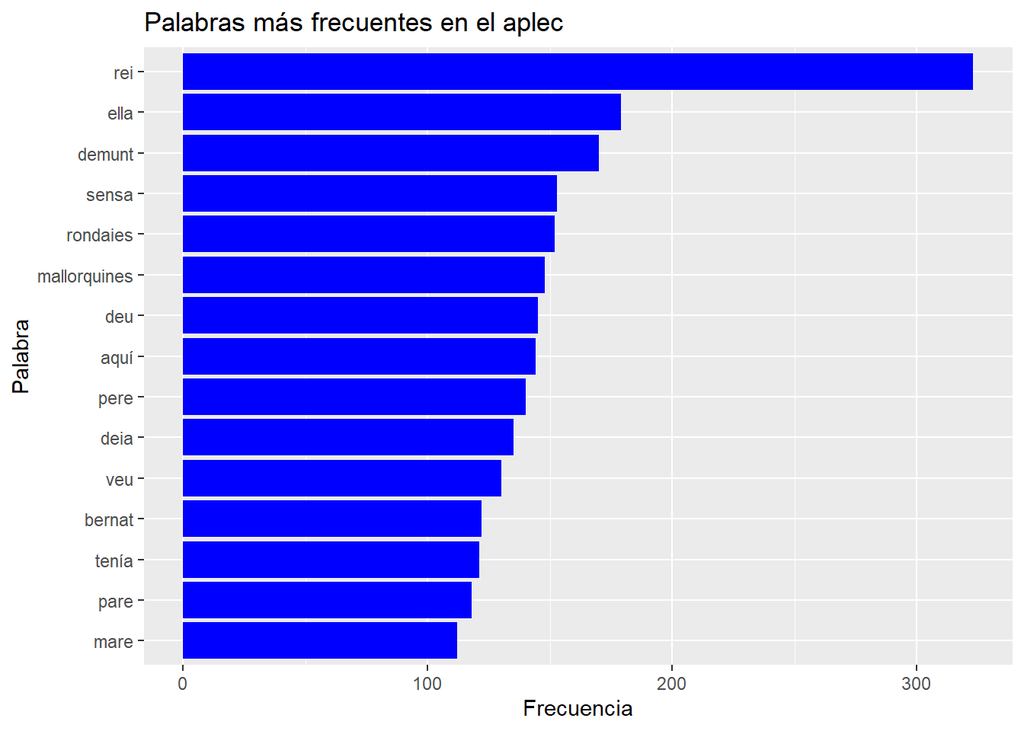

```r
freq_global %>%
  slice_max(n, n = 15) %>%
  ggplot(aes(x = reorder(paraula, n), y = n)) +
  geom_col(fill = "blue")+
  coord_flip() +
  labs(
    title = "Palabras más frecuentes en el aplec",
    x = "Palabra",
    y = "Frecuencia"
  )
```

### Pregunta 3

Vamos a representar la frecuencia frente a rango en escala normal

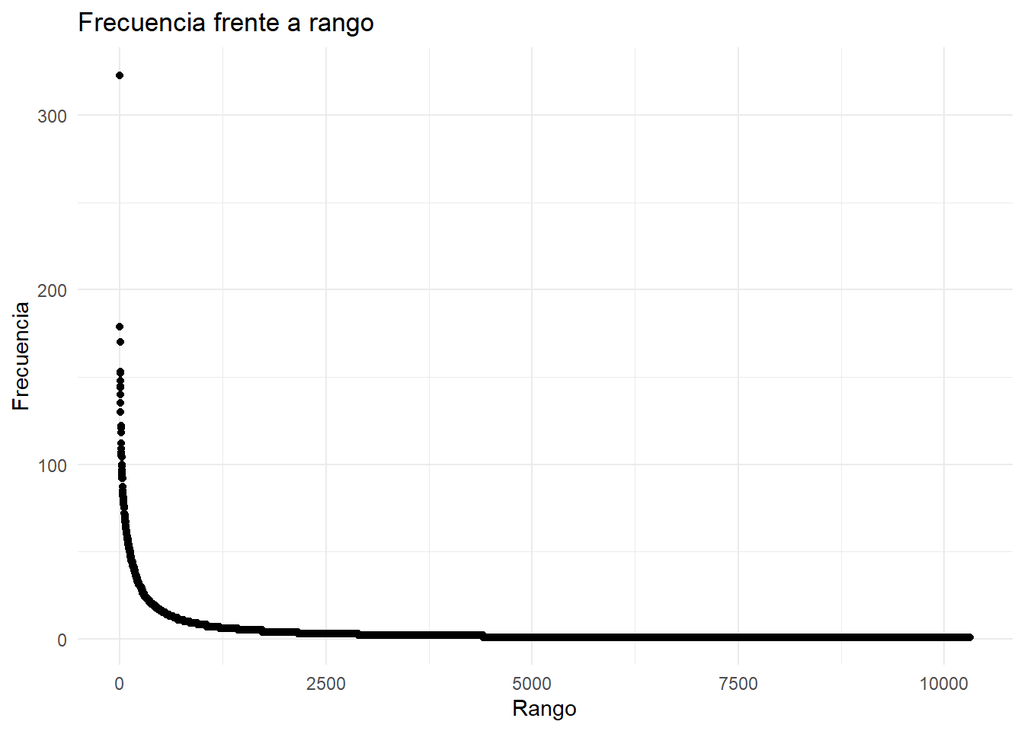

```r
freq_rank <- freq_global %>%
  mutate(rango = row_number())

ggplot(freq_rank, aes(x = rango, y = n)) +
  geom_point() +
  labs(
    title = "Frecuencia frente a rango",
    x = "Rango",
    y = "Frecuencia"
  ) +
  theme_minimal()
```

Este gráfico tiene forma curva debido a que las palabras que se repiten en un texto suelen ser pocas, mientras que las que no se repiten suelen ser un número mayor. Ahora veamos el mismo gráfico con escala logaritmica.

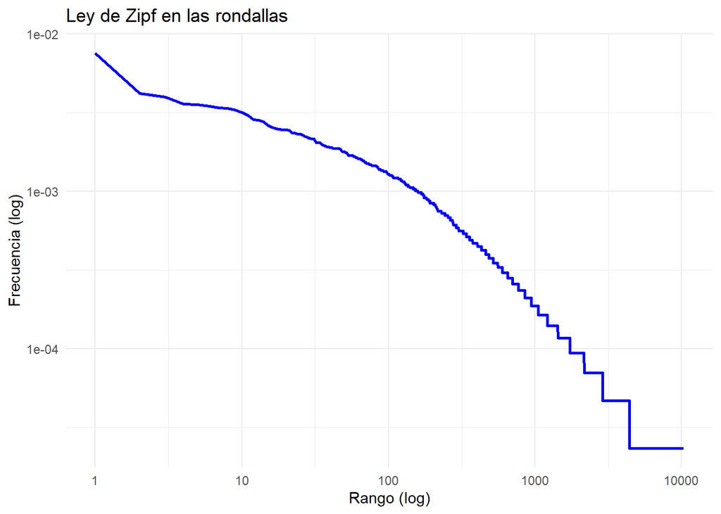

```r
zipf <- freq_global %>%
  mutate(rango = row_number(), tf = n/sum(n))

zipf %>%
  ggplot(aes(x = rango, y = tf)) +
  geom_line(color = "blue", linewidth = 1) +
  scale_x_log10() +
  scale_y_log10() +
  labs(
    title = "Ley de Zipf en las rondallas",
    x = "Rango (log)",
    y = "Frecuencia (log)"
  )+
  theme_minimal()
```

El gráfico en escala logarítmica muestra una tendencia aproximadamente lineal descendente, por lo que el patrón observado es compatible con la ley de Zipf. No obstante, no puede afirmarse que la cumpla perfectamente, ya que aparecen desviaciones en los rangos altos y bajos, probablemente debidas a palabras muy poco frecuentes, variantes lingüísticas y posibles errores de OCR.

Estudiemos ahora la ley de Zipf en cada rondalla:

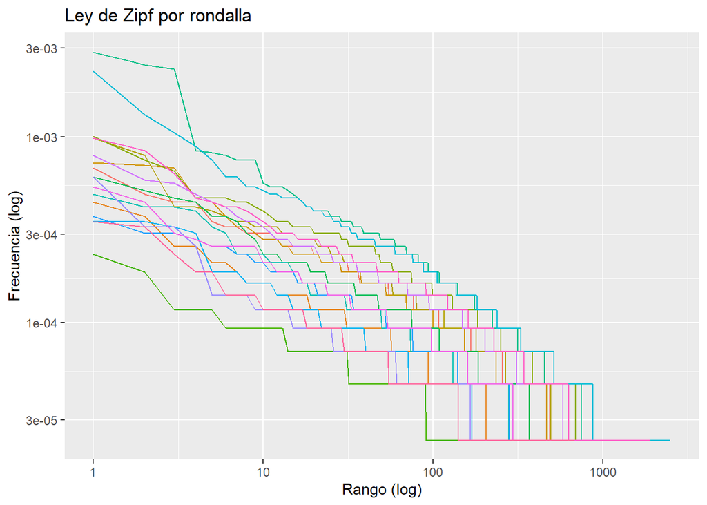

```r
freq_rondalla <- tokens2_net %>%
  count(titulo, paraula, sort = TRUE)

zipf_rondalla <- freq_rondalla %>%
  group_by(titulo) %>%
  arrange(desc(n), .by_group = TRUE) %>%
  mutate(rango = row_number()) %>%
  ungroup() # %>% filter(rango<980, rango>20)



zipf_rondalla %>%
  ggplot(aes(x = rango, y = n/sum(n), color = titulo)) +
  geom_line() +
  scale_x_log10() +
  scale_y_log10() +
  labs(
    title = "Ley de Zipf por rondalla",
    x = "Rango (log)",
    y = "Frecuencia (log)"
  ) +

  theme(legend.position = "none")
```

### Pregunta 4

En ausencia de una comparación directa con otro aplec, se ha dividido el Tomo 2 en dos bloques para estudiar si existen diferencias internas dentro del corpus. Esta comparación permite observar si el vocabulario se mantiene estable o si aparecen cambios temáticos entre las rondallas iniciales y finales.

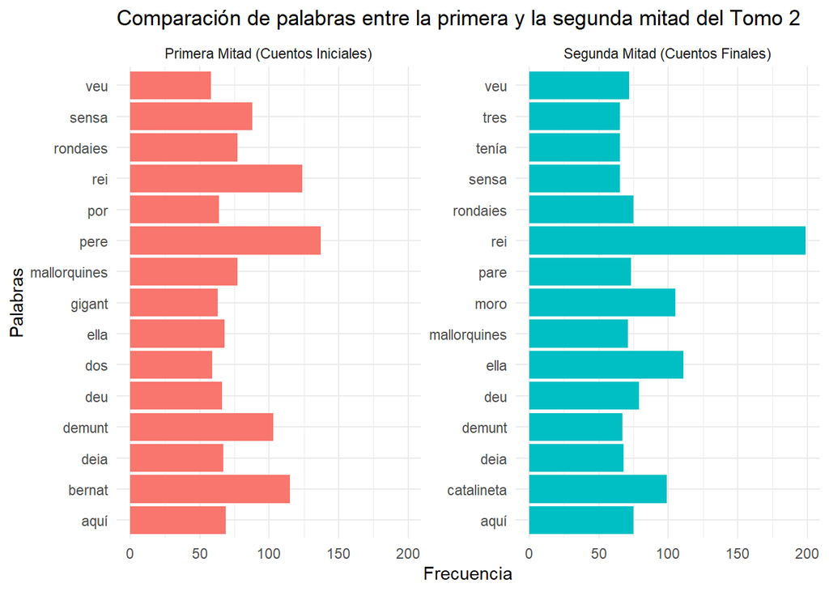

```r
# Encontrar el punto medio del número de rondallas
mitad_corte <- max(tokens2_net$id_rondalla) / 2

# Agrupar por mitades y sacar las 15 palabras más usadas en cada una
tokens2_net %>%
  mutate(mitad = ifelse(id_rondalla <= mitad_corte, "Primera Mitad (Cuentos Iniciales)", "Segunda Mitad (Cuentos Finales)")) %>%
  count(mitad, paraula) %>%
  group_by(mitad) %>%
  slice_max(n, n = 15) %>%
  ungroup() %>%
  mutate(word = reorder_within(paraula, n, mitad)) %>%
  ggplot(aes(n, paraula, fill = mitad)) +
  geom_col(show.legend = FALSE) +
  facet_wrap(~mitad, scales = "free_y") +
  scale_y_reordered() +
  labs(title = "Comparación de palabras entre la primera y la segunda mitad del Tomo 2",
       x = "Frecuencia",
       y = "Palabras") +
  theme_minimal()
```

### Pregunta 5

```r
tfidf <- tokens2_net %>%
  count(titulo, paraula) %>%
  bind_tf_idf(paraula, titulo, n)

tfidf
```

```
## # A tibble: 22,545 × 6
##    titulo          paraula      n       tf   idf   tf_idf
##    <chr>           <chr>    <int>    <dbl> <dbl>    <dbl>
##  1 EN GOSTÍ LLADRE abans        3 0.00105  0.268 0.000281
##  2 EN GOSTÍ LLADRE abastar      1 0.000350 2.14  0.000748
##  3 EN GOSTÍ LLADRE abor         1 0.000350 1.73  0.000607
##  4 EN GOSTÍ LLADRE abordat      1 0.000350 2.83  0.000991
##  5 EN GOSTÍ LLADRE acabada      1 0.000350 2.14  0.000748
##  6 EN GOSTÍ LLADRE acabades     1 0.000350 2.83  0.000991
##  7 EN GOSTÍ LLADRE acabava      1 0.000350 1.45  0.000506
##  8 EN GOSTÍ LLADRE acalar       1 0.000350 2.83  0.000991
##  9 EN GOSTÍ LLADRE acalat       2 0.000699 2.14  0.00150
## 10 EN GOSTÍ LLADRE acanalat     1 0.000350 1.73  0.000607
## # ℹ 22,535 more rows
```

```r
top_tfidf <- tfidf %>%
  group_by(titulo) %>%
  slice_max(tf_idf, n = 10) %>%
  ungroup()

top_tfidf
```

```
## # A tibble: 180 × 6
##    titulo          paraula      n      tf   idf  tf_idf
##    <chr>           <chr>    <int>   <dbl> <dbl>   <dbl>
##  1 EN GOSTÍ LLADRE gostí       29 0.0101   2.14 0.0217
##  2 EN GOSTÍ LLADRE massot      19 0.00664  2.14 0.0142
##  3 EN GOSTÍ LLADRE lladre      21 0.00734  1.45 0.0106
##  4 EN GOSTÍ LLADRE romanial    13 0.00455  2.14 0.00973
##  5 EN GOSTÍ LLADRE beina        9 0.00315  2.83 0.00892
##  6 EN GOSTÍ LLADRE flor        14 0.00490  1.73 0.00849
##  7 EN GOSTÍ LLADRE anyell      13 0.00455  1.73 0.00788
##  8 EN GOSTÍ LLADRE lladres     14 0.00490  1.45 0.00708
##  9 EN GOSTÍ LLADRE imeeel       7 0.00245  2.83 0.00693
## 10 EN GOSTÍ LLADRE fabiolet     6 0.00210  2.83 0.00594
## # ℹ 170 more rows
```

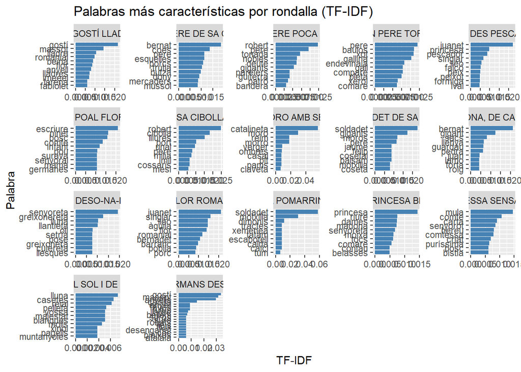

```r
top_tfidf %>%
  ggplot(aes(x = reorder_within(paraula, tf_idf, titulo), y = tf_idf)) +
  geom_col(fill = "steelblue") +
  coord_flip() +
  facet_wrap(~ titulo, scales = "free") +
  scale_x_reordered() +
  labs(
    title = "Palabras más características por rondalla (TF-IDF)",
    x = "Palabra",
    y = "TF-IDF"
  )
```

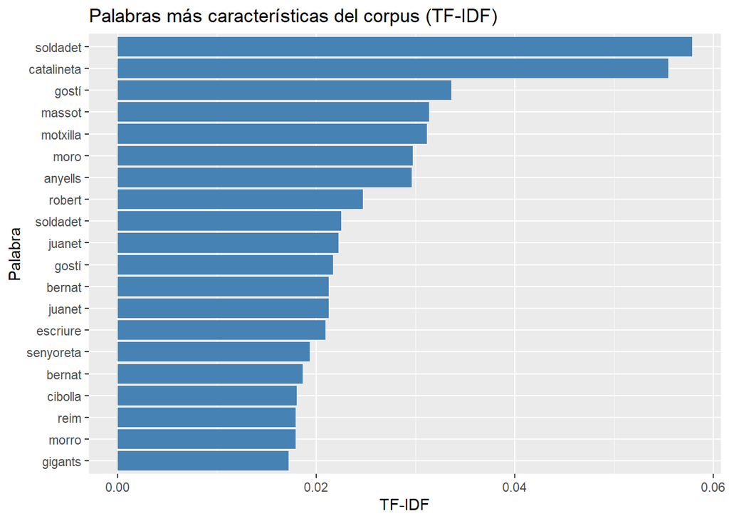

```r
tfidf %>%
  slice_max(tf_idf, n = 20, with_ties = FALSE) %>% # 'with_ties = FALSE' asegura exactamente 20 elementos
  ggplot(aes(x = reorder_within(paraula, tf_idf, tf_idf), y = tf_idf)) + # Forzamos el orden por el propio valor
  geom_col(fill = "steelblue") +
  coord_flip() +
  scale_x_reordered() + # Esto elimina los sufijos que añade reorder_within
  labs(
    title = "Palabras más características del corpus (TF-IDF)",
    x = "Palabra",
    y = "TF-IDF"
  )
```

Para saber qué hace especial a cada rondalla, hemos utilizado una métrica llamada *TF-IDF*. En lugar de mirar solo las palabras que más se repiten (que suelen ser siempre las mismas, como “el”, “la” o “que”), esta técnica nos ayuda a filtrar lo genérico para encontrar las palabras que realmente dan personalidad a cada historia.

Recordemos que el idf de una palabra es $\ln\frac{n_{documentos\ totales}}{n_{documentos\ que \ contienen \ la\ palabra}}$.

Vemos que las palabras que aparecen con un tf-idf alto son palabras poco comunes en general, (“soldadet”, “massot”, “motxilla”,…), o nombres propios de personajes, que son los protagonistas de las rondallas (“Catalineta”, “gostí”, “robert”, “juanet”,…).

También cabe mecionar el caso de la palabra “Catalineta”, que aparece con un tf-idf bastante alto, lo cual quiere decir que es una palabra poco común en todo el corpus, a pesar de que hemos visto que es una de las palabras que más aparecen en la segunda mitad de las rondallas del tomo 2 (de hecho, tiene un valor idf cercano a 3, de los más altos de la tabla).

Al observar los gráficos, podemos destacar los siguientes puntos clave:

Las palabras con mayor peso en el gráfico funcionan como indicadores del tema. Es decir, el gráfico nos permite identificar el tema principal de la historia de un vistazo, sin necesidad de leer el texto completo.

Cada rondalla tiene su propio perfil de palabras distintivas, lo que diferencia claramente un relato de otro dentro del mismo aplec.

Gracias a este filtrado, hemos logrado reducir la complejidad del texto. Esto es fundamental, ya que nos permite enfocarnos en lo que realmente hace única a cada narración, facilitando pasos posteriores como el modelo de tópicos o el estudio de las relaciones entre conceptos.

### Pregunta 6

Para aplicar el modelo Latent Dirichlet Allocation (LDA), primero necesitamos convertir nuestro recuento de palabras por rondalla en una matriz de documentos y términos (DTM). Se ha elegido trabajar con 3 tópicos porque permite obtener una división suficientemente interpretable del corpus sin fragmentar en exceso los resultados. Un número menor de tópicos agruparía temas demasiado generales, mientras que un número mayor podría generar temas difíciles de interpretar o demasiado dependientes de rondallas concretas. Por tanto, se adopta k = 3 como solución exploratoria equilibrada.

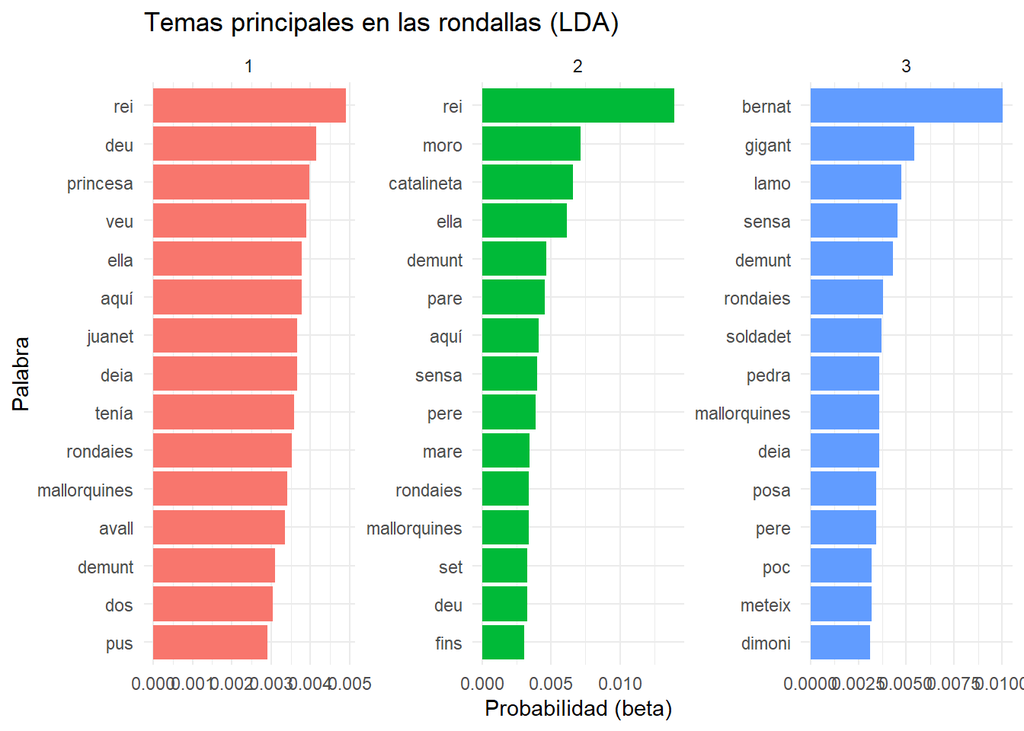

```r
# 1. Crear la matriz Document-Term (DTM)
dtm_rondallas <- tokens2_net %>%
  count(titulo, paraula) %>%
  cast_dtm(document = titulo, term = paraula, value = n)

# 2. Entrenar el modelo LDA con 3 temas (k = 3)
set.seed(1234)
lda_model <- LDA(dtm_rondallas, k = 3, control = list(seed = 1234))

# 3. Extraer las probabilidades de cada palabra por tema (matriz beta)
lda_topics <- tidy(lda_model, matrix = "beta")

# 4. Obtener las 15 palabras más probables de cada tema
top_terms_lda <- lda_topics %>%
  group_by(topic) %>%
  slice_max(beta, n = 15) %>%
  ungroup() %>%
  arrange(topic, -beta)

# 5. Visualizar los temas
top_terms_lda %>%
  mutate(term = reorder_within(term, beta, topic)) %>%
  ggplot(aes(x = term, y = beta, fill = factor(topic))) +
  geom_col(show.legend = FALSE) +
  facet_wrap(~ topic, scales = "free") +
  coord_flip() +
  scale_x_reordered() +
  labs(
    title = "Temas principales en las rondallas (LDA)",
    x = "Palabra",
    y = "Probabilidad (beta)"
  ) +
  theme_minimal()
```

#### Interpretación de los temas (LDA)

A partir de la distribución de las palabras con mayor probabilidad (beta) en cada uno de los 3 temas, podemos deducir que el modelo LDA ha agrupado los textos basándose principalmente en los **personajes protagonistas** de rondallas específicas.

### Pregunta 7

Para el calculo de los vectores se seleccionan las 150 palabras más frecuentes para facilitar la visualización y evitar que el gráfico quede saturado. Esta selección permite observar relaciones semánticas entre términos relevantes del corpus sin introducir demasiado ruido visual.

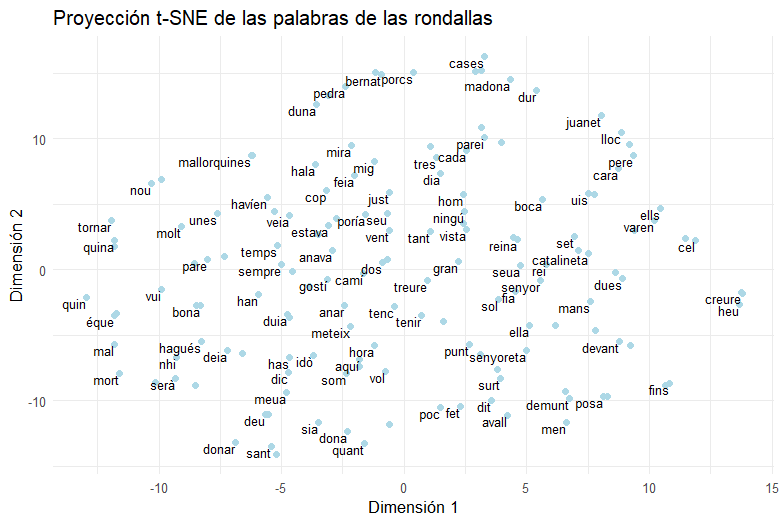

```r
# 1. Preparar el texto limpio (una cadena de texto por rondalla)
textos_limpios <- tokens2_net %>%
  group_by(titulo) %>%
  summarise(texto_unido = paste(paraula, collapse = " ")) %>%
  pull(texto_unido)

# 2. Entrenar el modelo word2vec (usamos skip-gram, dim = 50)
set.seed(1234)
modelo_w2v <- word2vec(x = textos_limpios, type = "skip-gram", dim = 50, iter = 20)

# 3. Extraer la matriz de embeddings
embeddings <- as.matrix(modelo_w2v)

# 4. Seleccionar las 150 palabras más frecuentes para visualizar
top_150_palabras <- freq_global %>%
  slice_max(n, n = 150) %>%
  pull(paraula)

# Filtrar la matriz para quedarnos solo con las palabras seleccionadas
emb_filtrados <- embeddings[rownames(embeddings) %in% top_150_palabras, ]

# 5. Proyectar a 2 dimensiones con t-SNE
set.seed(42)
tsne_res <- Rtsne(emb_filtrados, dims = 2, perplexity = 15, check_duplicates = FALSE)

# 6. Crear un dataframe y visualizar
df_tsne <- data.frame(
  paraula = rownames(emb_filtrados),
  X = tsne_res$Y[, 1],
  Y = tsne_res$Y[, 2]
)

grafico2 = df_tsne %>%
  ggplot(aes(x = X, y = Y, label = paraula)) +
  geom_point(color = "lightblue", size = 2) +
  geom_text(vjust = 1, hjust = 1, size = 3, check_overlap = TRUE) +
  theme_minimal() +
  labs(
    title = "Proyección t-SNE de las palabras de las rondallas",
    x = "Dimensión 1",
    y = "Dimensión 2"
  )
```

#### Interpretación de la proyección semántica (Word2Vec y t-SNE)

Al proyectar las palabras más frecuentes en un plano bidimensional mediante t-SNE con una perplejidad de 15, observamos que **no se forman agrupaciones (“clústers”) hiperdefinidas o aisladas**, sino que los términos se distribuyen formando una nube difusa o continuo semántico.

Lejos de ser un error, este comportamiento es esperable y se explica por dos limitaciones metodológicas y narrativas:

1. **Limitación del volumen de datos:** Los modelos de *word embeddings* como Word2Vec necesitan corpus gigantescos (de millones de palabras) para que los vectores generen repulsiones fuertes y formen “islas” separadas. Un solo tomo de rondallas representa un corpus relativamente pequeño, limitando la diferenciación espacial extrema de los vectores.
2. **Estructura narrativa fuertemente interconectada:** En los cuentos tradicionales, los contextos se solapan constantemente. Un “rei” interactúa con un “dimoni”, un “gigant” va a un “castell”, y la “princesa” huye al “bosc”. Como casi todos los personajes y objetos mágicos comparten las mismas acciones y espacios narrativos, Word2Vec los aproxima en el espacio multidimensional.

A pesar de ser un continuo, sí se pueden apreciar **afinidades relativas** en el espacio:

- La zona central del gráfico concentra principalmente vocabulario muy frecuente y estructural del relato. Aparecen palabras como “just”, “treure”, “tenir”, “tenc”, “anar” o “anava”.
- En las zonas más periféricas aparecen términos asociados a contextos más específicos o menos conectados. En la parte superior destacan palabras como “bernat”, “porcs”, “cases” o “madona”, mientras que hacia la derecha aparecen términos como “cel”, “creure” o “heu”. Por otro lado, en la región inferior izquierda se observan palabras como “mort”, “deu”, “sant” o “donar”.

A pesar de esta dispersión espacial, no se forman clústers completamente aislados, lo que sugiere que el vocabulario de las rondallas mantiene una estructura narrativa global altamente interconectada.

Para aislar comunidades semánticas de forma más estricta y sortear este solapamiento de los *embeddings*, resulta necesario aplicar un umbral de similitud duro, aproximación que se desarrollará mediante el análisis de redes en el siguiente apartado.

### Pregunta 8

```r
# 1. Calcular la matriz de similitud del coseno
# Normalizamos los vectores primero para que el producto matricial sea igual al coseno
norm_emb <- emb_filtrados / sqrt(rowSums(emb_filtrados^2))
sim_matrix <- norm_emb %*% t(norm_emb)

# 2. Aplicar un umbral (threshold) para podar el grafo
umbral <- 0.4 # Puedes subir o bajar este valor para hacer el grafo más o menos denso
adj_matrix <- sim_matrix
adj_matrix[adj_matrix < umbral] <- 0
diag(adj_matrix) <- 0 # Eliminar auto-bucles

# 3. Construir el grafo con igraph
grafo_palabras <- graph_from_adjacency_matrix(
  adj_matrix,
  mode = "undirected",
  weighted = TRUE
)

# Eliminar nodos aislados (palabras sin conexiones tras aplicar el umbral)
grafo_palabras <- delete_vertices(grafo_palabras, degree(grafo_palabras) == 0)

# 4. Detectar comunidades (algoritmo de Louvain)
comunidades <- cluster_louvain(grafo_palabras)
V(grafo_palabras)$comunidad <- as.factor(membership(comunidades))

# 5. Calcular la centralidad de Eigenvector para ver qué palabras son más centrales
centralidad <- eigen_centrality(grafo_palabras)$vector
V(grafo_palabras)$centralidad <- centralidad

# Mostrar las 10 palabras más centrales en la consola
top_centrales <- data.frame(
  palabra = V(grafo_palabras)$name,
  centralidad = centralidad
) %>% arrange(desc(centralidad))

head(top_centrales, 10)
```

```
##        palabra centralidad
## ella      ella   1.0000000
## sobre    sobre   0.9370788
## cosa      cosa   0.8464536
## aquí      aquí   0.8216503
## tenía    tenía   0.8010302
## rei        rei   0.7806785
## homo      homo   0.7773572
## encara  encara   0.7629572
## seua      seua   0.7408962
## meteix  meteix   0.7403209
```

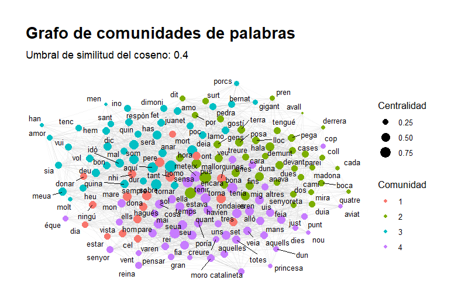

```r
# 6. Visualizar el grafo de comunidades con ggraph
set.seed(2023)
grafico = ggraph(grafo_palabras, layout = "fr") +
  geom_edge_link(aes(edge_alpha = weight), show.legend = FALSE, color = "gray80") +
  geom_node_point(aes(color = comunidad, size = centralidad)) +
  geom_node_text(aes(label = name), repel = TRUE, size = 3, max.overlaps = Inf) +
  theme_graph() +
  labs(
    title = "Grafo de comunidades de palabras",
    subtitle = paste("Umbral de similitud del coseno:", umbral),
    color = "Comunidad",
    size = "Centralidad"
  )
```

#### Interpretación de la red de similitud y comunidades (Grafo y Centralidad)

**1. Análisis de Centralidad (Eigenvector)** Para cuantificar la importancia de cada palabra en la red, se ha utilizado la centralidad de vector propio (*Eigenvector centrality*), la cual se obtiene a partir del vector propio dominante de la matriz de adyacencia del grafo. Esta métrica no solo evalúa el número de conexiones de un nodo, sino la calidad de estas (estar conectado a nodos que a su vez son muy influyentes).

Al observar los 10 nodos más centrales de la tabla, extraemos dos conclusiones clave:

### Disclaimer de uso de IA

En este trabajo colaborativo, se utilizaron los modelos de lenguaje a gran escala ChatGPT (OpenAI) y Microsoft Copilot como herramientas de soporte. Estas tecnologías se emplearon exclusivamente para la optimización en la búsqueda de referencias académicas y la elaboración de resúmenes preliminares de los documentos analizados. Los autores revisaron, contrastaron y complementaron críticamente toda la información obtenida, aportando los comentarios, análisis y conclusiones finales presentes en este documento.